# Time Series

2018-02-10 12:24:43 -0600

```r
suppressPackageStartupMessages({
  library(TSA)
  library(forecast)
  library(ggplot2)
  library(dplyr)
})
```

# Binary Random Walk

Assume $Y_t$ is a *binary* random walk such as
$$\begin{cases}
Y_1 = e_1\\
Y_2 = e_1 + e_2\\
\vdots\\
Y_t = \sum_{i=1}^t e_i
\end{cases}$$
where $e_i\in\{-1,1\}$ i.i.d

Note that this is not the Gaussian random walk where $e_t\sim N(0,1)$ but a binary one where $e_t$ can only take two values: $-1$ and $1$ each with probability 50%.

## Question 1

### a)

Please compute analytically:

$E[Y_3]=$

```r
E_Y3 <- 0
```

(please include only the numerical answer above not the computation. An acceptable format for your answer is such as `E_Y3 <- 5`. Please do not rename this variable)

### b)

Please compute analytically:

$\mathrm{Var}[Y_3] =$

```r
Var_Y3 <- 3
```

### c)

Please compute analytically:

$\mathrm{Cov}(Y_2,Y_3) =$

```r
Cov_Y2Y3 <- 2
```

### d)

Please compute analytically:

$\mathrm{Corr}(Y_2,Y_3) =$

```r
Corr_Y2Y3 <- 0.816
```

### e)

Please compute analytically:

$\mathrm{Cov}(Y_5,Y_{10}) =$

```r
Cov_Y5Y10 <- 5
```

### f)

Please compute analytically:

$\mathrm{Corr}(Y_5,Y_{10}) =$

```r
Corr_Y5Y10 <- 0.707
```

## Question 2

### a)

Please generate one sample path of length $T=100$ for this binary random walk.

- Please save it into a data.frame `df2a` column `df2a$Y`

```r
set.seed(42) # Please do not change the seed

T <- 100L

e <- sample(c(-1,1), T, replace = TRUE)

df2a <- data.frame(t = 1:T, Y = cumsum(e))
```

### b)

Please generate $N=100$ sample paths of length $T=100$ for this binary random walk.

- Please save the results into a data.frame `df2b` where:
  - column `df2b$Y` has the values of the process
  - column `df2b$id` has the id of the sample path
  - column `df2b$t` has the time

**Hints:**

- use `dplyr` chains like we did during the workday
- don’t forget to `ungroup()` when you are doing a `group_by()`

```r
set.seed(42) # Please do not change the seed

N <- 100L
T <- 100L

binary_df_b <- data.frame(e = sample(c(-1,1), N*T, replace = TRUE))

df2b <- binary_df_b %>%
  mutate(t = rep(1:T, N),
         id = rep(1:N, each=T)) %>%
  group_by(id) %>%
  mutate(Y = cumsum(e)) %>%
  ungroup()
```

### c)

Please plot the sample paths that you generated in the previous question

- Please save your plot into variable `p2c` and plot it

**Hints:**

- use `ggplot` and take advantage of the long format of the data
- please don’t change the color (keep the lines black) but do put `alpha=0.1` into your `geom_line` to make sample paths somewhat transparent.
- do not use `geom_points` just `geom_line` is fine
- As you will see from your plot:
  - the fainter the line the less likely the random walk would reach this spot

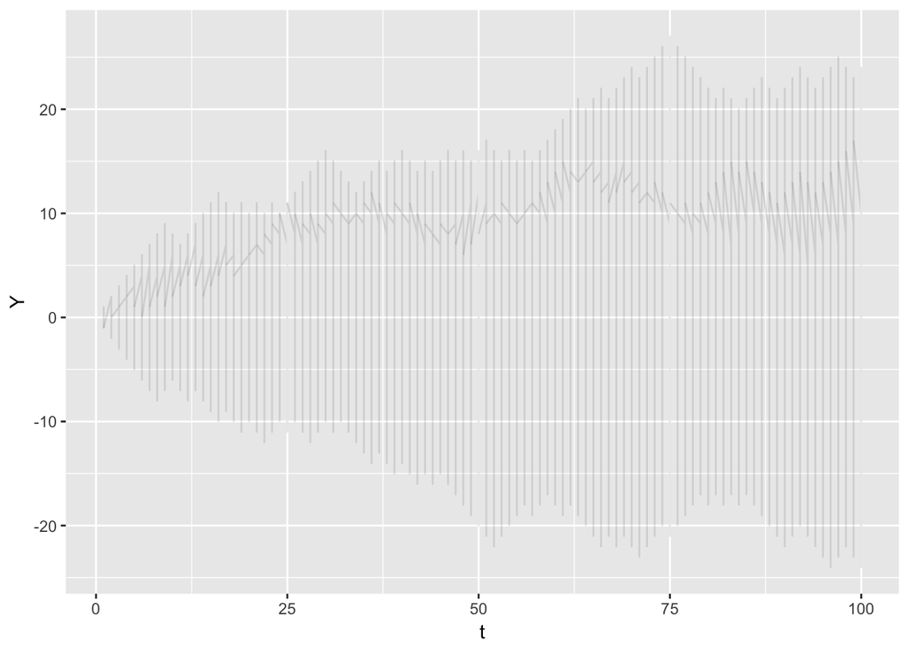

```r
p2c <- ggplot(df2b) +
  geom_line(aes(x=t,y=Y), alpha=0.1)
p2c
```

### d)

Please use the code that you wrote before to generate $N=5000L$ sample paths.

- Please save the result into `df2d` data.frame following conventions of the prior question
  - column `df2d$Y` has the values of the process
  - column `df2d$id` has the id of the sample path
  - column `df2d$t` has the time

```r
set.seed(42) # Please do not change the seed

N <- 5000L
T <- 100L

binary_df_d <- data.frame(e = sample(c(-1,1), N*T, replace = TRUE))

df2d <- binary_df_d %>%
  mutate(t = rep(1:T, N),
         id = rep(1:N, each=T)) %>%
  group_by(id) %>%
  mutate(Y = cumsum(e)) %>%
  ungroup()
```

### e)

Assume now that you just got a phone call from your friend telling you that this random walk has just been observed to pass through the point $Y_6 = 6$.

- What that means is you know that all first 6 steps of the random walk happened to be in the “up” direction not “down”.

In other words, as this new information from your friend became you can refine your forecast: you can remove the sample paths that the process has not taken and only concentrate on the remaining sample paths that it could still take

- This idea is simulation-based forecasting

Please create data.frame `df2e` such that it only has the sample paths (and only those sample paths) from the previous answer that satisfy the condition that $Y_6 = 6$.

**Hints**:

- use `group_by`
- the cleanest way is to use dplyr’s `do()`
- less clean but also doable: you could create a separate data.frame with acceptable sample path ids and then `inner_join` it to the main data.frame to keep only the good sample paths in it.

```r
df2e <- df2d %>%
  mutate(V = ifelse(t==6&Y==6, 1, 0)) %>%
  filter(V == 1) %>%
  select(one_of('id')) %>%
  left_join(df2d, by='id')
```

### f)

Please use the data.frame from the previous question to plot your results.

**Key takeaways:**

- You should see from your plot why people say that random walks have memory and are not mean reverting.
- This idea of sequentially eliminating sample paths as you observe the process in order to forecast the future better is called *filtration*. This idea is fundamental in continuous-time stochastic processes but we will only touch upon it for discrete-time stochastic processes.

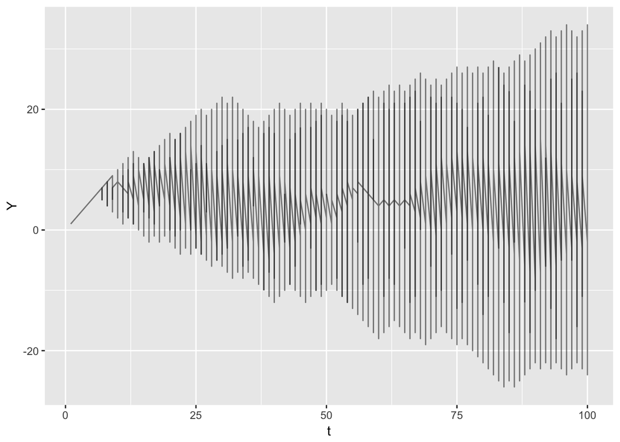

```r
# please plot it here
p2f <- ggplot(df2e) +
  geom_line(aes(x=t,y=Y), alpha=0.5)
p2f
```